# Finding the Molar mass of Caffeine & its Formal Charges

Author

Jascyn Bell

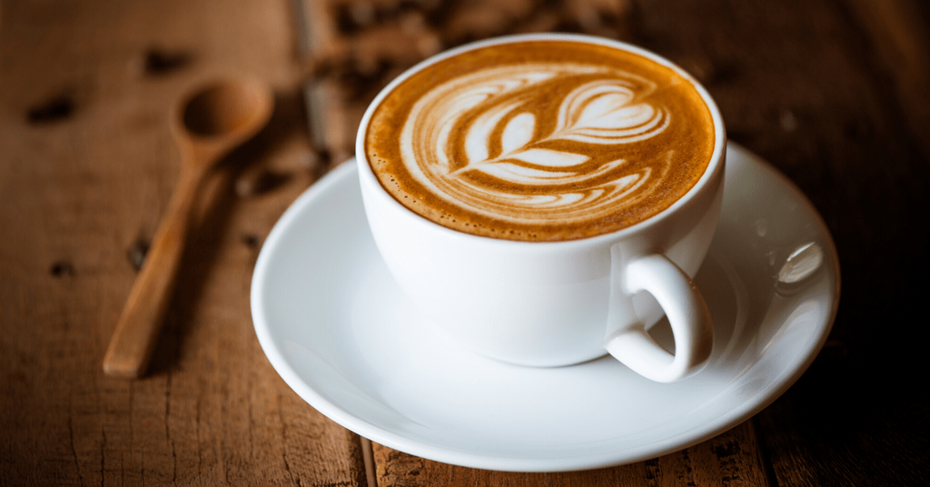

For my Final Project, I decided to find the molar mass of caffeine and the formal charges of the individual atoms which it is composed of. Furthermore, I will be employing pandas to create a table to display the atomic masses of the individual atoms in the molecular formula of caffeine. After defining the atomic masses, I will utilize sympy to create the equation for both formal charge and molecular formula. Lastly, I will recruit matplotlib to display a graph of my atomic charges.

Finding the atomic mass of a molecule is easy! Mainly because you re only adding the atomic masses of different atoms the molecule is composed of.

$\ce{C8H10N4O2}$

As you can clearly see, caffeine has 8 Carbons, 10 Hydrogens, 4 Nitrogens and 2 oxygens. In order to display the chemical symbols and subscripts, I used a branch of LaTex called **mchem**

```
include-in-header:
      text:\usepackage[version=4]{mhchem}
```

In this case, I will be using pandas to show the atomic masses of the Hydrogen, Carbon, Nitrogen, and Oxygen atoms found in caffeine

```python
import pandas as pd

df = pd.read_csv("Caffeine Content - Sheet1 (1).csv")

df
```

|  | Atomic Name | Atomic Mass |
| --- | --- | --- |
| 0 | Carbon | 12.011 |
| 1 | Hydrogen | 1.008 |
| 2 | Nitrogen | 14.007 |
| 3 | Oxygen | 15.999 |

In here, I plugged a data sheet link Which I definitely did not create just now for this example to be read by pandas and it procures a chart based on what was present in the sheet data.

```python
import sympy as sy
from sympy import symbols, latex

Carbon = 12.011 * 8

Hydrogen = 1.008 * 10

Nitrogen = 14.007 * 4

Oxygen = 15.999 *2

sy.pprint(Carbon + Hydrogen + Nitrogen + Oxygen)
```

```
194.194
```

From using subsets of sympy, I calculated the molecular mass

# Finding formal charge

The formal charge of an atom is known as:

$$(The # of valence electrons) - (the # of lone pairs of electrons) - (# of bonds / 2)$$

In order to make use out of this formula, we need the molecular structure for caffeine as well as the number of valence shells of each atom.

[figure not shown]

Getting this image from overleaf.com, I can find the number of bonds needed for the equations.

[output not shown]

For my final portion of the project, I wanted to display the differences in formal charge through graphing.

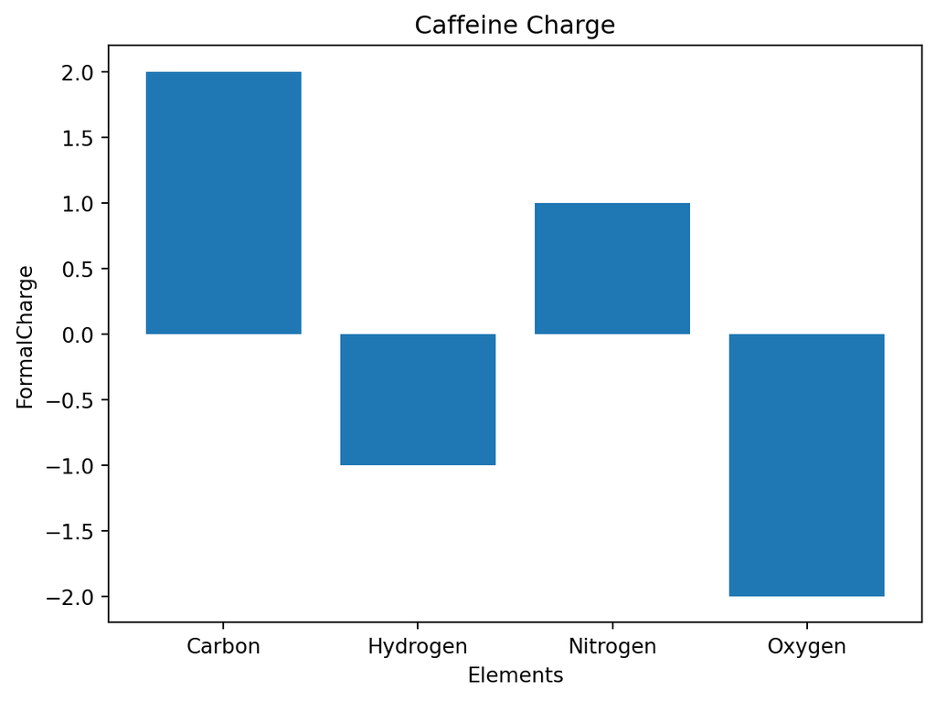

```python
import matplotlib.pyplot as plt
import numpy as np

Elements = ['Carbon', 'Hydrogen', 'Nitrogen', 'Oxygen']
FormalCharge = [2, -1,1, -2]

plt.bar(Elements, FormalCharge)
plt.title('Caffeine Charge')
plt.xlabel('Elements')
plt.ylabel('FormalCharge')
plt.show()
```

In conclusion, you can see that Carbon has the largest formal charge while oxygen has the lowest.

This graph was made possible with matplotlib!

The ==plt== command made it possible for different features of matplotlib to be edited, and could only be displayed by the command ==plt.show==

By using matplotlib for graphing data, LaTex for formatting equations, and Pandas for turning data into a table chart, I can use python to explain complex topics such as molecular structure and formal charge.

Working on this final has been an experience,

- I learned the nuances of packages (mhchem program within LaTex)
- How to create a website on github
- Editing images and website formatting

Goodnight.